# Laptop Value

# The Question

Is weight a good variable for explaining a laptop’s price? More specifically, can I determine if what I paid for my laptop was a good price using it’s weight? To answer this question, I will use data collected on laptops, filtered to match some of the specifications of my own laptop. I own a Lenovo tablet stlye laptop and it has a Inte Core i5 processor and 8Gb of RAM. All of the laptops in my dataset match at least these two features.

Looking below, you will see the laptop data plotted by weight and price.

[figure not shown]

```r
ggplot() +
  geom_point(data = core_i5, aes(x = Weight_lbs, y = Price_USD), alpha = 0.8, col = "#0e9aa7") +
  geom_point(data = my_laptop_actual, aes(x = Weight_lbs, y = Price_USD, col = Name), size = 2) +
  geom_point(data = my_laptop_predicted, aes(x = Weight_lbs, y = Price_USD, col = Name), size = 2) +
  scale_colour_manual(name = "", values = c("#fe8a71", "#f6cd61")) +
  geom_line(data = regression, aes(x = Weight_lbs, y = Price_USD), col = "#4a4e4d", alpha = 0.3) +
  geom_abline(intercept = mean(core_i5$Price_USD), slope = 0, linetype = "dashed", alpha = 0.3, col = "#4a4e4d") +
  geom_text(aes(x = 6.5, y = mean(core_i5$Price_USD) + 100, label = "Mean Price"), alpha = 0.5) +
  geom_abline(intercept  = laptop.lm$coefficients[1], slope = laptop.lm$coefficients[2], size = 1, alpha = 0.2, col = "#4a4e4d") +
  geom_abline(intercept  = laptop.lm$coefficients[1] + ResErr, slope = laptop.lm$coefficients[2], linetype = "dashed", alpha = 0.2, col = "#4a4e4d") +
  geom_abline(intercept  = laptop.lm$coefficients[1] + (2 * ResErr), slope = laptop.lm$coefficients[2], linetype = "dashed", alpha = 0.2, col = "#4a4e4d") +
  geom_abline(intercept  = laptop.lm$coefficients[1] - ResErr, slope = laptop.lm$coefficients[2], linetype = "dashed", alpha = 0.2, col = "#4a4e4d") +
  geom_abline(intercept  = laptop.lm$coefficients[1] - (2 * ResErr), slope = laptop.lm$coefficients[2], linetype = "dashed", alpha = 0.2, col = "#4a4e4d") +
  theme_classic() +
  theme(legend.justification = c(-2, -3), legend.position = c(0.1, 0), plot.title = element_text(hjust = 0.5), plot.subtitle = element_text(hjust = 0.5)) +
  labs(title = "Weight vs. Price: Did I pay a fair price for my laptop?",
       subtitle = "There appears to be a strong negative correlation between a laptop's weight and it's price.",
       x = "Weight (Pounds)", y = "Price (USD)",
       caption = "I paid $650 for my laptop which weighs 2.73 pounds. This model predicts that I should have paid more than $1,500.")
```

[figure not shown]

```r
# no dots
ggplot() +
  geom_point(data = core_i5, aes(x = Weight_lbs, y = Price_USD), alpha = 0, col = "#0e9aa7") +
  geom_point(data = my_laptop_actual, aes(x = Weight_lbs, y = Price_USD, col = Name), size = 2) +
  geom_point(data = my_laptop_predicted, aes(x = Weight_lbs, y = Price_USD, col = Name), size = 2) +
  scale_colour_manual(name = "", values = c("#fe8a71", "#f6cd61")) +
  geom_abline(intercept = mean(core_i5$Price_USD), slope = 0, linetype = "dashed", alpha = 0.3, col = "#4a4e4d") +
  geom_text(aes(x = 6.5, y = mean(core_i5$Price_USD) + 100, label = "Mean Price"), alpha = 0.5) +
  geom_line(data = regression, aes(x = Weight_lbs, y = Price_USD), col = "#4a4e4d", alpha = 0.8) +
  geom_text(aes(x = my_laptop_actual$Weight_lbs + 0.5, y = 1100, label = paste("-$", residual))) +
  geom_abline(intercept  = laptop.lm$coefficients[1], slope = laptop.lm$coefficients[2], size = 1, alpha = 0.5, col = "#4a4e4d") +
  geom_text(aes(x = 2.25, y = laptop.lm$coefficients[1] - ResErr, label = "Regression Line"), angle = -17, alpha = 0.5, col = "#4a4e4d") +
  geom_abline(intercept  = laptop.lm$coefficients[1] + ResErr, slope = laptop.lm$coefficients[2], linetype = "dashed", alpha = 0.5, col = "#4a4e4d") +
  geom_text(aes(x = 2.25, y = laptop.lm$coefficients[1], label = "+1 Std. Error"), angle = -17, alpha = 0.5, col = "#4a4e4d") +
  geom_abline(intercept  = laptop.lm$coefficients[1] + (2 * ResErr), slope = laptop.lm$coefficients[2], linetype = "dashed", alpha = 0.5, col = "#4a4e4d") +
  geom_text(aes(x = 2.25, y = laptop.lm$coefficients[1] + ResErr, label = "+2 Std. Error"), angle = -17, alpha = 0.5, col = "#4a4e4d") +
  geom_abline(intercept  = laptop.lm$coefficients[1] - ResErr, slope = laptop.lm$coefficients[2], linetype = "dashed", alpha = 0.5, col = "#4a4e4d") +
  geom_text(aes(x = 2.25, y = laptop.lm$coefficients[1] - (2 * ResErr), label = "-1 Std. Error"), angle = -17, alpha = 0.5, col = "#4a4e4d") +
  geom_abline(intercept  = laptop.lm$coefficients[1] - (2 * ResErr), slope = laptop.lm$coefficients[2], linetype = "dashed", alpha = 0.5, col = "#4a4e4d") +
  geom_text(aes(x = 2.25, y = laptop.lm$coefficients[1] - (3 * ResErr), label = "-2 Std. Error"), angle = -17, alpha = 0.5, col = "#4a4e4d") +
  theme_classic() +
  theme(legend.justification = c(-2, -3), legend.position = c(0.1, 0), plot.title = element_text(hjust = 0.5), plot.subtitle = element_text(hjust = 0.5)) +
  labs(title = "Weight vs. Price: Did I pay a fair price for my laptop?",
       subtitle = "There appears to be a strong negative correlation between a laptop's weight and it's price.",
       x = "Weight (Pounds)", y = "Price (USD)",
       caption = "According to the model, the price I paid for my laptop is found more than two residual standard errors from the predicted price.")
```

Seeing that what I paid for my laptop is two standard erros from the predicted value, I am suspicious of the accuracy it’s accuracy. Maybe the data isn’t a good fit for this regression.

## Analysis

$$H_0: \beta_1 \text{(estimate slope)} = 0 \text{ Weight (pounds) } \textbf{does not } \text{help us understand the mean price of laptops with the same family of processors and same amount of RAM.}$$

$$H_a: \beta_1 \text{(estimate slope)} \neq 0 \text{ Weight (pounds) } \textbf{does } \text{help us understand the mean price of laptops with the same family of processors and same amount of RAM.}$$

$$\alpha: 0.05$$

```r
kable(core_i5[1:100,]) %>%
  kable_styling() %>%
  scroll_box(width = "100%", height = "500px")
```

| X1 | Company | Product | TypeName | Inches | ScreenResolution | Cpu | RamSize | RamUnits | MemorySize | MemorySizeUnits | MemoryType | Gpu | OpSys | Weight | Price_euros | MemorySizeGB | Price_USD | has_core_i5 | Weight_num | Weight_lbs |
| --- | --- | --- | --- | --- | --- | --- | --- | --- | --- | --- | --- | --- | --- | --- | --- | --- | --- | --- | --- | --- |
| 1 | Apple | MacBook Pro | Ultrabook | 13.3 | IPS Panel Retina Display 2560x1600 | Intel Core i5 2.3GHz | 8 | GB | 8 | GB | SSD | Intel Iris Plus Graphics 640 | macOS | 1.37kg | 1339.69 | 128 | 1522.8942 | TRUE | 1.370 | 3.0140 |
| 2 | Apple | Macbook Air | Ultrabook | 13.3 | 1440x900 | Intel Core i5 1.8GHz | 8 | GB | 8 | GB | Flash Storage | Intel HD Graphics 6000 | macOS | 1.34kg | 898.94 | 128 | 1021.8711 | TRUE | 1.340 | 2.9480 |
| 3 | HP | 250 G6 | Notebook | 15.6 | Full HD 1920x1080 | Intel Core i5 7200U 2.5GHz | 8 | GB | 8 | GB | SSD | Intel HD Graphics 620 | No OS | 1.86kg | 575.00 | 256 | 653.6319 | TRUE | 1.860 | 4.0920 |
| 5 | Apple | MacBook Pro | Ultrabook | 13.3 | IPS Panel Retina Display 2560x1600 | Intel Core i5 3.1GHz | 8 | GB | 8 | GB | SSD | Intel Iris Plus Graphics 650 | macOS | 1.37kg | 1803.60 | 256 | 2050.2444 | TRUE | 1.370 | 3.0140 |
| 8 | Apple | Macbook Air | Ultrabook | 13.3 | 1440x900 | Intel Core i5 1.8GHz | 8 | GB | 8 | GB | Flash Storage | Intel HD Graphics 6000 | macOS | 1.34kg | 1158.70 | 256 | 1317.1536 | TRUE | 1.340 | 2.9480 |
| 10 | Acer | Swift 3 | Ultrabook | 14.0 | IPS Panel Full HD 1920x1080 | Intel Core i5 8250U 1.6GHz | 8 | GB | 8 | GB | SSD | Intel UHD Graphics 620 | Windows 10 | 1.6kg | 770.00 | 256 | 875.2984 | TRUE | 1.600 | 3.5200 |
| 16 | Apple | MacBook Pro | Ultrabook | 13.3 | IPS Panel Retina Display 2560x1600 | Intel Core i5 2.3GHz | 8 | GB | 8 | GB | SSD | Intel Iris Plus Graphics 640 | macOS | 1.37kg | 1518.55 | 256 | 1726.2135 | TRUE | 1.370 | 3.0140 |
| 20 | Dell | XPS 13 | Ultrabook | 13.3 | IPS Panel Full HD / Touchscreen 1920x1080 | Intel Core i5 8250U 1.6GHz | 8 | GB | 8 | GB | SSD | Intel UHD Graphics 620 | Windows 10 | 1.22kg | 979.00 | 128 | 1112.8794 | TRUE | 1.220 | 2.6840 |
| 22 | Lenovo | Legion Y520-15IKBN | Gaming | 15.6 | IPS Panel Full HD 1920x1080 | Intel Core i5 7300HQ 2.5GHz | 8 | GB | 8 | GB | SSD + 1TB HDD | Nvidia GeForce GTX 1050 | Windows 10 | 2.5kg | 999.00 | 128 | 1135.6144 | TRUE | 2.500 | 5.5000 |
| 24 | Dell | Inspiron 5379 | 2 in 1 Convertible | 13.3 | Full HD / Touchscreen 1920x1080 | Intel Core i5 8250U 1.6GHz | 8 | GB | 8 | GB | SSD | Intel UHD Graphics 620 | Windows 10 | 1.62kg | 819.00 | 256 | 930.9992 | TRUE | 1.620 | 3.5640 |
| 27 | Apple | MacBook Air | Ultrabook | 13.3 | 1440x900 | Intel Core i5 1.6GHz | 8 | GB | 8 | GB | Flash Storage | Intel HD Graphics 6000 | Mac OS X | 1.35kg | 1099.00 | 128 | 1249.2895 | TRUE | 1.350 | 2.9700 |
| 28 | Dell | Inspiron 5570 | Notebook | 15.6 | Full HD 1920x1080 | Intel Core i5 8250U 1.6GHz | 8 | GB | 8 | GB | SSD | AMD Radeon 530 | Windows 10 | 2.2kg | 800.00 | 256 | 909.4009 | TRUE | 2.200 | 4.8400 |
| 30 | HP | ProBook 470 | Notebook | 17.3 | Full HD 1920x1080 | Intel Core i5 8250U 1.6GHz | 8 | GB | 8 | TB | HDD | Nvidia GeForce 930MX | Windows 10 | 2.5kg | 896.00 | 1000 | 1018.5290 | TRUE | 2.500 | 5.5000 |
| 35 | Apple | MacBook Air | Ultrabook | 13.3 | 1440x900 | Intel Core i5 1.6GHz | 8 | GB | 8 | GB | Flash Storage | Intel HD Graphics 6000 | Mac OS X | 1.35kg | 998.00 | 256 | 1134.4777 | TRUE | 1.350 | 2.9700 |
| 38 | Dell | Inspiron 5770 | Notebook | 17.3 | IPS Panel Full HD 1920x1080 | Intel Core i5 8250U 1.6GHz | 8 | GB | 8 | GB | SSD + 1TB HDD | AMD Radeon 530 | Windows 10 | 2.8kg | 979.00 | 128 | 1112.8794 | TRUE | 2.800 | 6.1600 |
| 40 | HP | ProBook 450 | Notebook | 15.6 | Full HD 1920x1080 | Intel Core i5 8250U 1.6GHz | 8 | GB | 8 | GB | SSD | Nvidia GeForce 930MX | Windows 10 | 2.1kg | 879.00 | 256 | 999.2043 | TRUE | 2.100 | 4.6200 |
| 43 | Asus | X542UQ-GO005 (i5-7200U/8GB/1TB/GeForce | Notebook | 15.6 | 1366x768 | Intel Core i5 7200U 2.5GHz | 8 | GB | 8 | TB | HDD | Nvidia GeForce 940MX | Linux | 2.3kg | 522.99 | 1000 | 594.5095 | TRUE | 2.300 | 5.0600 |
| 46 | Apple | MacBook Pro | Ultrabook | 13.3 | IPS Panel Retina Display 2560x1600 | Intel Core i5 2.0GHz | 8 | GB | 8 | GB | SSD | Intel Iris Graphics 540 | macOS | 1.37kg | 1419.00 | 256 | 1613.0499 | TRUE | 1.370 | 3.0140 |
| 62 | Dell | Vostro 5471 | Ultrabook | 14.0 | Full HD 1920x1080 | Intel Core i5 8250U 1.6GHz | 8 | GB | 8 | GB | SSD | Intel UHD Graphics 620 | Windows 10 | 1.7kg | 879.00 | 256 | 999.2043 | TRUE | 1.700 | 3.7400 |
| 64 | Asus | UX410UA-GV350T (i5-8250U/8GB/256GB/FHD/W10) | Notebook | 14.0 | Full HD 1920x1080 | Intel Core i5 8250U 1.6GHz | 8 | GB | 8 | GB | SSD | Intel UHD Graphics 620 | Windows 10 | 1.4kg | 941.00 | 256 | 1069.6828 | TRUE | 1.400 | 3.0800 |
| 66 | HP | 250 G6 | Notebook | 15.6 | Full HD 1920x1080 | Intel Core i5 7200U 2.5GHz | 8 | GB | 8 | GB | SSD | Intel HD Graphics 620 | Windows 10 | 1.86kg | 690.00 | 256 | 784.3583 | TRUE | 1.860 | 4.0920 |
| 75 | MSI | GL72M 7RDX | Gaming | 17.3 | Full HD 1920x1080 | Intel Core i5 7300HQ 2.5GHz | 8 | GB | 8 | GB | SSD + 1TB HDD | Nvidia GeForce GTX 1050 | Windows 10 | 2.7kg | 1095.00 | 128 | 1244.7425 | TRUE | 2.700 | 5.9400 |
| 78 | Lenovo | IdeaPad 320-15IKBN | Notebook | 15.6 | Full HD 1920x1080 | Intel Core i5 7200U 2.5GHz | 8 | GB | 8 | TB | HDD | Intel HD Graphics 620 | No OS | 2.2kg | 519.00 | 2000 | 589.9739 | TRUE | 2.200 | 4.8400 |
| 81 | HP | ProBook 470 | Notebook | 17.3 | Full HD 1920x1080 | Intel Core i5 8250U 1.6GHz | 8 | GB | 8 | GB | SSD + 1TB HDD | Nvidia GeForce 930MX | Windows 10 | 2.5kg | 977.00 | 128 | 1110.6059 | TRUE | 2.500 | 5.5000 |
| 82 | Dell | Latitude 5590 | Ultrabook | 15.6 | IPS Panel Full HD 1920x1080 | Intel Core i5 8250U 1.6GHz | 8 | GB | 8 | GB | SSD | Intel UHD Graphics 620 | Windows 10 | 1.88kg | 1096.16 | 256 | 1246.0612 | TRUE | 1.880 | 4.1360 |
| 83 | Apple | MacBook 12" | Ultrabook | 12.0 | IPS Panel Retina Display 2304x1440 | Intel Core i5 1.3GHz | 8 | GB | 8 | GB | SSD | Intel HD Graphics 615 | macOS | 0.92kg | 1510.00 | 512 | 1716.4943 | TRUE | 0.920 | 2.0240 |
| 84 | HP | ProBook 440 | Notebook | 14.0 | Full HD 1920x1080 | Intel Core i5 8250U 1.6GHz | 8 | GB | 8 | GB | SSD | Intel HD Graphics 620 | Windows 10 | 1.63kg | 860.00 | 256 | 977.6060 | TRUE | 1.630 | 3.5860 |
| 89 | HP | 250 G6 | Notebook | 15.6 | Full HD 1920x1080 | Intel Core i5 7200U 2.5GHz | 8 | GB | 8 | GB | SSD | Intel HD Graphics 620 | Windows 10 | 1.96kg | 598.99 | 256 | 680.9026 | TRUE | 1.960 | 4.3120 |
| 95 | Dell | Inspiron 7577 | Gaming | 15.6 | Full HD 1920x1080 | Intel Core i5 7300HQ 2.5GHz | 8 | GB | 8 | GB | SSD | Nvidia GeForce GTX 1060 | Windows 10 | 2.65kg | 1195.00 | 256 | 1358.4176 | TRUE | 2.650 | 5.8300 |
| 97 | Acer | Spin 5 | 2 in 1 Convertible | 13.3 | IPS Panel Full HD / Touchscreen 1920x1080 | Intel Core i5 8250U 1.6GHz | 8 | GB | 8 | GB | SSD | Intel UHD Graphics 620 | Windows 10 | 1.5kg | 847.00 | 256 | 962.8282 | TRUE | 1.500 | 3.3000 |

[output cut: 70 more lines]

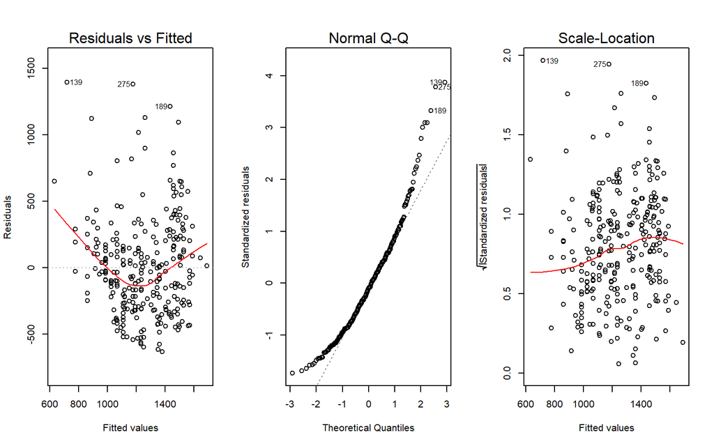

```r
par(mfrow = c(1,3))
plot(laptop.lm, which = 1:3)
```

The Residuals vs Fitted plot illustrates the data has constant variance but doesn’t have a solid linear relationship. The Q-Q plot gives us reason to believe the error terms are not normal. The Scale-Location plot shows a small trend in the points, so all together, this data doesn’t meet the necessary assumptions to make an appropriate regression.

##### Regression Summary

```r
summary(laptop.lm)
```

```
Call:
lm(formula = Price_USD ~ Weight_lbs, data = core_i5)

Residuals:
    Min      1Q  Median      3Q     Max
-633.12 -271.40  -34.23  192.60 1395.62

Coefficients:
            Estimate Std. Error t value Pr(>|t|)
(Intercept)  2027.96      83.27  24.355   <2e-16 ***
Weight_lbs   -189.36      19.62  -9.651   <2e-16 ***
---
Signif. codes:  0 '***' 0.001 '**' 0.01 '*' 0.05 '.' 0.1 ' ' 1

Residual standard error: 365.6 on 287 degrees of freedom
Multiple R-squared:  0.245, Adjusted R-squared:  0.2424
F-statistic: 93.15 on 1 and 287 DF,  p-value: < 2.2e-16
```

##### Price Number Summary

```r
pander(favstats(core_i5$Price_USD))
```

| min | Q1 | median | Q3 | max | mean | sd | n | missing |
| --- | --- | --- | --- | --- | --- | --- | --- | --- |
| 590 | 943.5 | 1150 | 1529 | 2649 | 1252 | 420 | 289 | 0 |

##### Weight Number Summary

```r
pander(favstats(core_i5$Weight_lbs))
```

| min | Q1 | median | Q3 | max | mean | sd | n | missing |
| --- | --- | --- | --- | --- | --- | --- | --- | --- |
| 1.782 | 3.08 | 4.18 | 4.84 | 7.37 | 4.1 | 1.098 | 289 | 0 |